# Limma Analysis of Cox Preeclampsia GSE75010 Study

Kyle Campbell - November 6th, 2020

## Load and format data

Load normalized expression data and cleaned metadata from script “GSE75010_preprocess.Rmd”.

```r
expr <- read.csv(paste0(data_dir, "GSE75010_complete_dataset.csv.gz"))
meta <- readRDS(paste0(data_dir, "GSE75010_merged_abundances2020-10-16.rda"))
#gse <- getGEO("GSE75010", GSEMatrix = TRUE)
```

Based on the phenoData, this array platform is single color.

```r
#colnames(gse$GSE75010_series_matrix.txt.gz@phenoData@data)
```

Reformat expression data to a matrix with genes as rownames.

```r
genes <- expr %>% dplyr::select(X)
rownames(expr) <- genes$X
expr <- expr %>% dplyr::select(-X)
expr <- as.matrix(expr)
```

Initialize an expression set object.

```r
d <- ExpressionSet(expr)
# Clean-up
rm (gse, genes, expr)
```

Add metadata.

```r
# Drop p-value, correlation, and RMSE
meta <- meta[,1:19]
pData(d) <- meta
# Clean-up
rm(meta)
```

## PCA projection

PCA for low-dimensional representation.

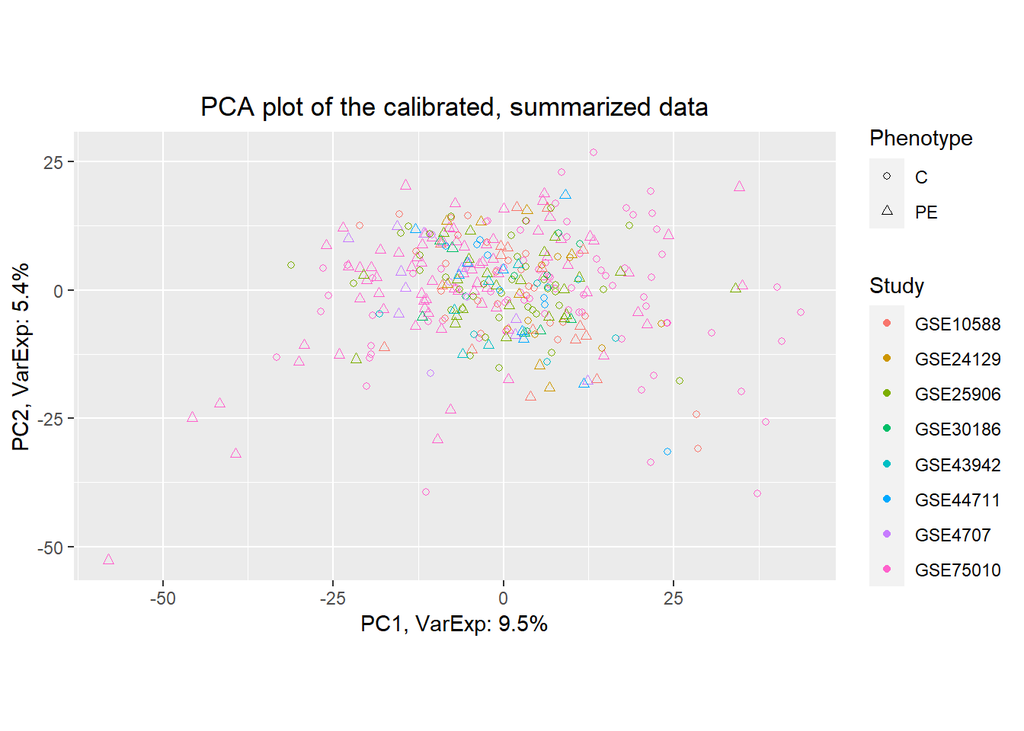

```r
PCA <- prcomp(t(exprs(d)), scale = FALSE)
percentVar <- round(100*PCA$sdev^2/sum(PCA$sdev^2),1)
sd_ratio <- sqrt(percentVar[2] / percentVar[1])

pca.dataGG <- data.frame(PC1 = PCA$x[,1], PC2 = PCA$x[,2],
                    Study =
                     pData(d)$batch,
                    Phenotype =
                     pData(d)$phenotype)
ggplot(pca.dataGG, aes(PC1, PC2)) +
      geom_point(aes(shape = Phenotype, colour = Study)) +
  ggtitle("PCA plot of the calibrated, summarized data") +
  xlab(paste0("PC1, VarExp: ", percentVar[1], "%")) +
  ylab(paste0("PC2, VarExp: ", percentVar[2], "%")) +
  theme(plot.title = element_text(hjust = 0.5)) +
  coord_fixed(ratio = sd_ratio) +
  scale_shape_manual(values = c(1:8))
```

```r
covariates <- c("phenotype", "sex", "ga", "batch")
phenotype <- phenoData(d)$phenotype
sex <- phenoData(d)$sex
ga <- phenoData(d)$ga
batch <- phenoData(d)$batch

design.formula <- as.formula(paste0("~", paste(covariates, collapse = " + ")))
design <- model.matrix(design.formula)
```

Fit the model.

```r
fit <- lmFit(d, design)
fit <- eBayes(fit)
```

Extract model results.

```r
hits <- topTable(fit, coef = "phenotypePE", number = Inf)
```

Histogram of raw p-values

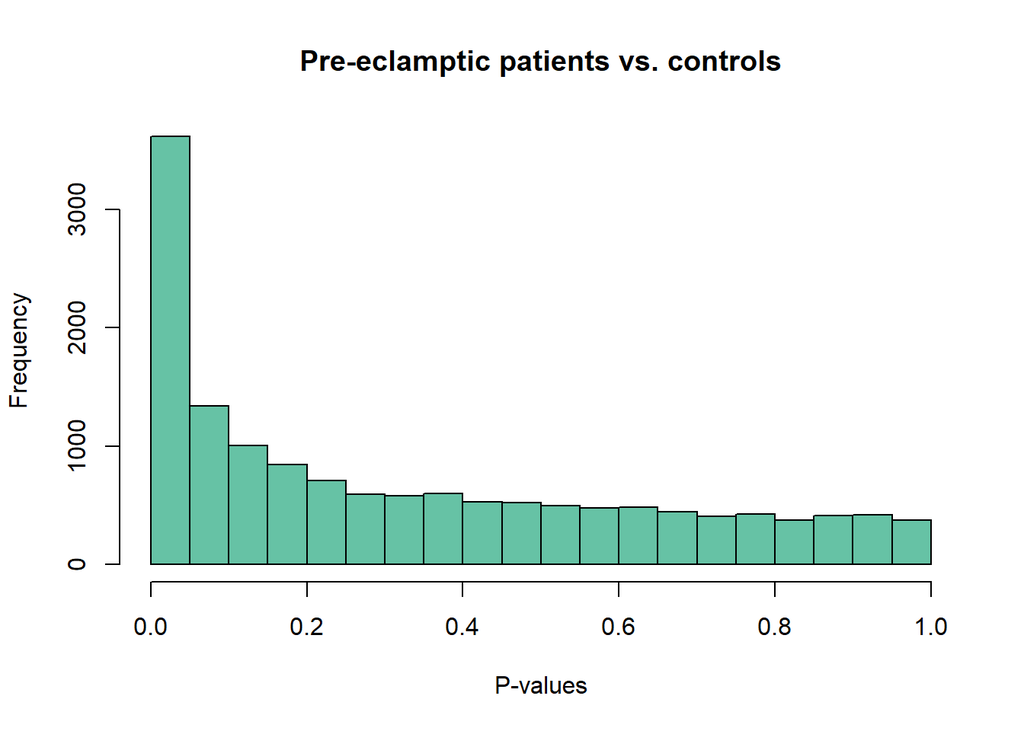

```r
hist(hits$P.Value, col = brewer.pal(3, name = "Set2")[1],
     main = "Pre-eclamptic patients vs. controls", xlab = "P-values")
```

Histogram of FDR-adjusted p-values.

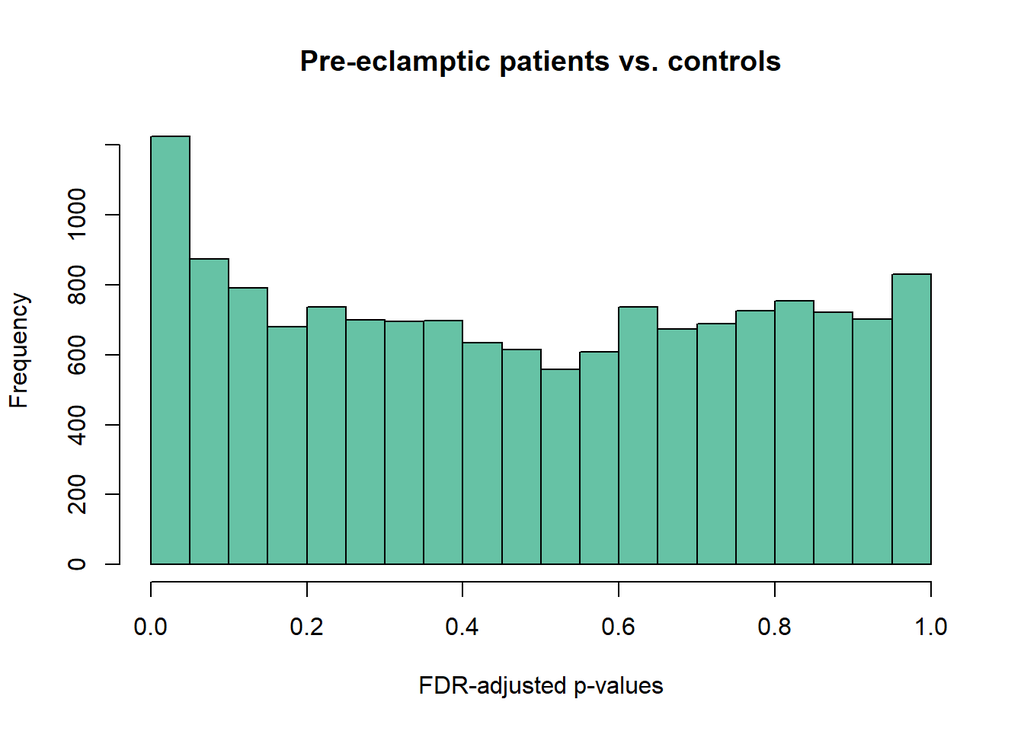

```r
hist(hits$adj.P.Val, col = brewer.pal(3, name = "Set2")[1],
     main = "Pre-eclamptic patients vs. controls", xlab = "FDR-adjusted p-values")
```

## Report results

Add boolean significance vector to our results table.

```r
# Set p-value threshold
threshold <- .05
hits$sig <- hits$adj.P.Val < threshold
print(paste0(length(which(hits$sig)), " significant hits at FDR-adjusted cutoff of ", threshold))
```

```
## [1] "1224 significant hits at FDR-adjusted cutoff of 0.05"
```

```r
res <- rownames_to_column(hits, "gene_symbol")
```

Get the top hits.

```r
# Get the top downregulated hits
downreg <- res %>%
  filter(adj.P.Val < .05) %>%
  filter(logFC < 0) %>%
  arrange(logFC)
#Get the top upregulated hits.
upreg <- res %>%
  filter(adj.P.Val < .05) %>%
  filter(logFC > 0) %>%
  arrange(desc(logFC))
```

Label genes of interest by name, the top 10 upregulated and downregulated hits and hand-chosen extravillous trophoblast marker gene HLA-G.

```r
num.to.plot <- 10
genes.of.interest <- c("HLA-G")
top.upreg <- upreg$gene_symbol[1:num.to.plot]
top.downreg <- downreg$gene_symbol[1:num.to.plot]
genes.to.plot <- c(top.upreg, top.downreg, genes.of.interest)
res$label[(res$gene_symbol %in% genes.to.plot)] <- T
```

Volcano plot of results. The chunk above will determine which genes are labelled in the plot.

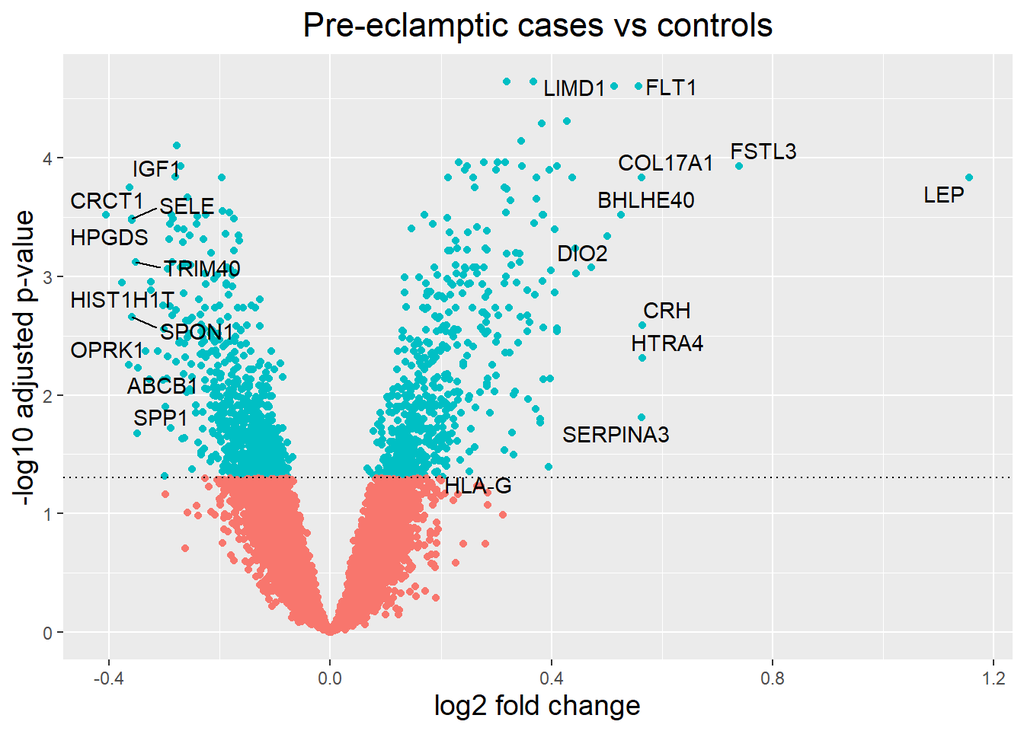

```r
# Volcano plot
plot1 <- ggplot(res) +
        geom_point(aes(x=logFC, y=-log10(adj.P.Val), colour=sig)) +
        geom_text_repel(aes(x = logFC, y = -log10(adj.P.Val),
                            label = ifelse(
                              label, gene_symbol, ""
                            ))) +
        geom_hline(yintercept = -log10(threshold), linetype="dotted") +
        ggtitle("Pre-eclamptic cases vs controls") +
        xlab("log2 fold change") +
        ylab("-log10 adjusted p-value") +
        theme(legend.position = "none",
              plot.title = element_text(size = rel(1.5), hjust = 0.5),
              axis.title = element_text(size = rel(1.25)))
plot1
```

## Defining and fitting the cell type proportion-adjusted model

```r
covariates <- c("phenotype", "sex", "ga", "batch", "naive_t_cells", "hofabuer_cells", "fibroblasts", "cd14_monocytes", "activated_t_cells", "extravillous_trophoblasts")
phenotype <- phenoData(d)$phenotype
sex <- phenoData(d)$sex
ga <- phenoData(d)$ga
batch <- phenoData(d)$batch
naive_t_cells <- phenoData(d)$naive_t_cells
hofabuer_cells <-  phenoData(d)$hofbauer_cells
fibroblasts <-  phenoData(d)$fibroblasts
cd14_monocytes <- phenoData(d)$cd14_monocytes
activated_t_cells <- d$activated_t_cells
extravillous_trophoblasts <- d$extravillous_trophoblasts

design.formula <- as.formula(paste0("~", paste(covariates, collapse = " + ")))
design <- model.matrix(design.formula)
```

Fit the model.

```r
fit <- lmFit(d, design)
fit <- eBayes(fit)
```

Extract model results.

```r
hits <- topTable(fit, coef = "phenotypePE", number = Inf)
```

Histogram of raw p-values.

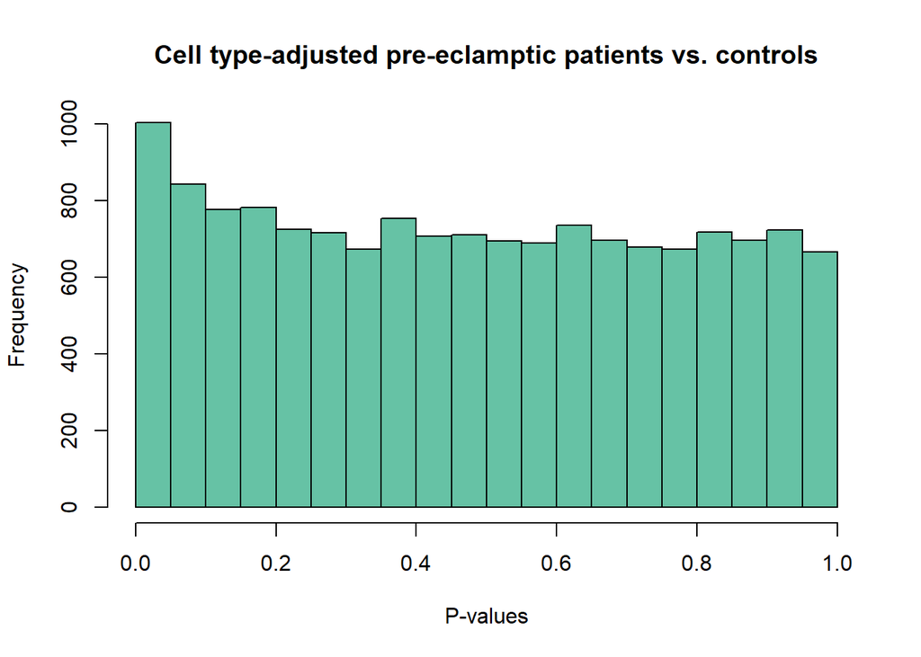

```r
hist(hits$P.Value, col = brewer.pal(3, name = "Set2")[1],
     main = "Cell type-adjusted pre-eclamptic patients vs. controls", xlab = "P-values")
```

Histogram of FDR-adjusted p-values.

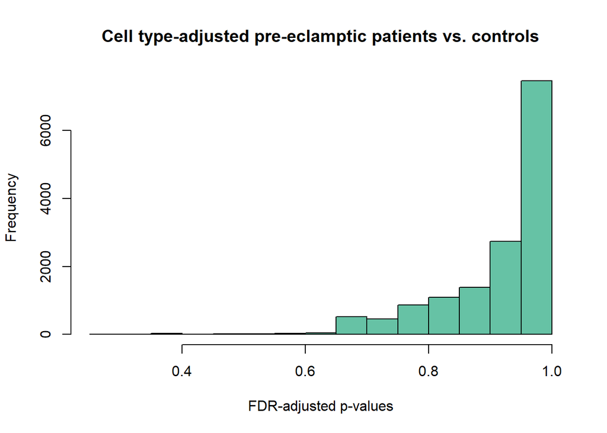

```r
hist(hits$adj.P.Val, col = brewer.pal(3, name = "Set2")[1],
     main = "Cell type-adjusted pre-eclamptic patients vs. controls", xlab = "FDR-adjusted p-values")
```

## Report results

```r
# Set p-value threshold
threshold <- .3
hits$sig <- hits$adj.P.Val < threshold
print(paste0(length(which(hits$sig)), " significant hits at FDR-adjusted cutoff of ", threshold))
```

```
## [1] "9 significant hits at FDR-adjusted cutoff of 0.3"
```

```r
res <- rownames_to_column(hits, "gene_symbol")
```

Get the top hits.

```r
# Get the top downregulated hits
downreg <- res %>%
  filter(adj.P.Val < threshold) %>%
  filter(logFC < 0) %>%
  arrange(logFC)
#Get the top upregulated hits.
upreg <- res %>%
  filter(adj.P.Val < threshold) %>%
  filter(logFC > 0) %>%
  arrange(desc(logFC))
```

Label genes of interest by name. Because there are limited hits, plot all hits at FDR-adjusted p-value threshold. Also included a label for the extreme outlier “LEP.”

```r
#num.to.plot <- 10
#genes.of.interest <- c("HLA-G")
#top.upreg <- upreg$gene_symbol[1:num.to.plot]
#top.downreg <- downreg$gene_symbol[1:num.to.plot]
#genes.to.plot <- c(top.upreg, top.downreg, genes.of.interest)
logFC.outlier <- res %>%
  filter(logFC > .41)
all.hits <- res %>%
  filter(adj.P.Val < threshold)
genes.to.plot <- c(all.hits$gene_symbol, logFC.outlier$gene_symbol)
res$label[(res$gene_symbol %in% genes.to.plot)] <- T
```

Volcano plot of results. The chunk above will determine which genes are labelled in the plot.

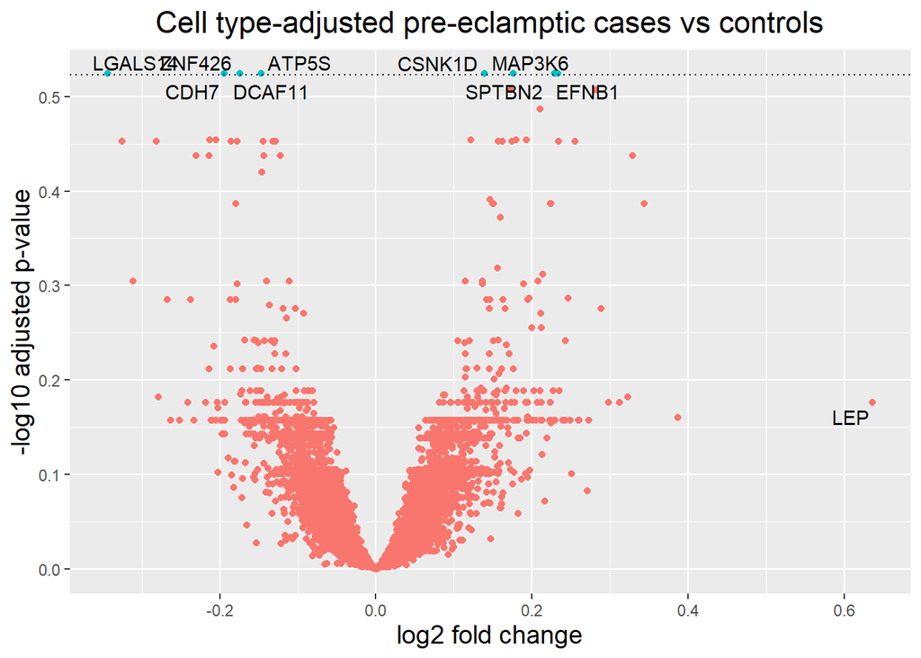

```r
# Volcano plot
plot2 <- ggplot(res) +
        geom_point(aes(x=logFC, y=-log10(adj.P.Val), colour=sig)) +
        geom_text_repel(aes(x = logFC, y = -log10(adj.P.Val),
                            label = ifelse(
                              label, gene_symbol, ""
                            ))) +
        geom_hline(yintercept = -log10(threshold), linetype="dotted") +
        ggtitle("Cell type-adjusted pre-eclamptic cases vs controls") +
        xlab("log2 fold change") +
        ylab("-log10 adjusted p-value") +
        theme(legend.position = "none",
              plot.title = element_text(size = rel(1.5), hjust = 0.5),
              axis.title = element_text(size = rel(1.25)))
plot2
```

Manually set axis limits and drawing side-by-side.

```r
p1 <- plot1 + coord_cartesian(xlim = c(-.45, 1.2), ylim = c(0, 5)) + ggtitle("Unadjusted")
#ggsave(paste0(data_dir, "GSE75010_dex_unadj_", Sys.Date(), ".png"), device = png())
p2 <- plot2 + coord_cartesian(xlim = c(-.45, 1.2), ylim = c(0, 5)) + ggtitle("Cell type-adjusted") +
  geom_hline(yintercept = -log10(.05), linetype="dotted")
#ggsave(paste0(data_dir, "GSE75010_dex_adj_", Sys.Date(), ".png"), device = png())
```

Draw and save.

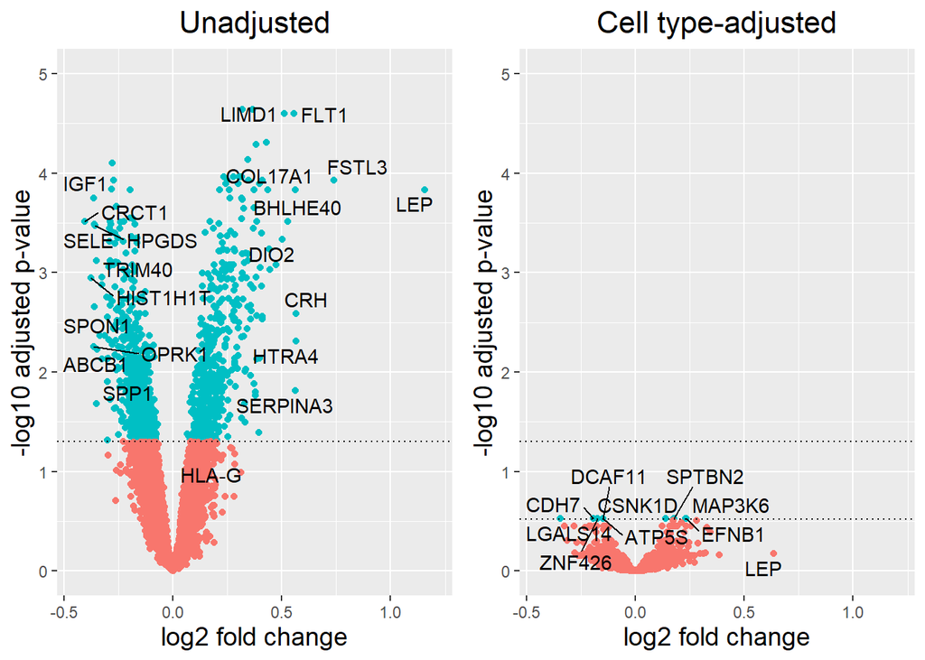

```r
#png(paste0(data_dir, "GSE75010_dex_2_panel", Sys.Date(), ".png"))
grid.newpage()
grid.draw(cbind(ggplotGrob(p1), ggplotGrob(p2)))
```

```r
#dev.off()
```